# South Dade Conveyance System Environmental Information

Point of Contact: Paul Julian (paul.julian@dep.state.fl.us)

*Please note this analysis is for informational purposes only and subject to change.*

# Hydrologic Information

Provided in this section are peroid of record (POR) discharge data and associated metrics of avialable data in the South Florida Water Management Districts [DBHYDRO](http://my.sfwmd.gov/dbhydroplsql/show_dbkey_info.main_menu). All structure DBKEYs used to construct these discharge time-series can be found in this [file](http://publicfiles.dep.state.fl.us/owp/SouthDade_Info/DataInventory_existing.xlsx).

[interactive chart not shown]

Interactive map of structures monitored within the South Dade Conveyance System. Currently no data is availabel for S328 (D-Detention Area) or G737 (Frog Pond Detention Area).

Below are a series of plots for each structure with accessible/available data. Only positive flows were used in this analysis. Reverse flow has been observed at some strucutres. The three plots are flow-duration curves using daily data for the entire POR for any given structure (left), daily discharge volume (middle) and total discahrge volume based on the Florida Water Year (right). The lower flow-duration limit (20% Exceedance) for each strcture has been identified where applicable. All hydrologic data is presented in m<sup>3</sup> d<sup>-1</sup> or m<sup>3</sup> WY<sup>-1</sup>, to convert from m<sup>3</sup> to Acre-Feet, multiply values by 0.000810714.

## S331

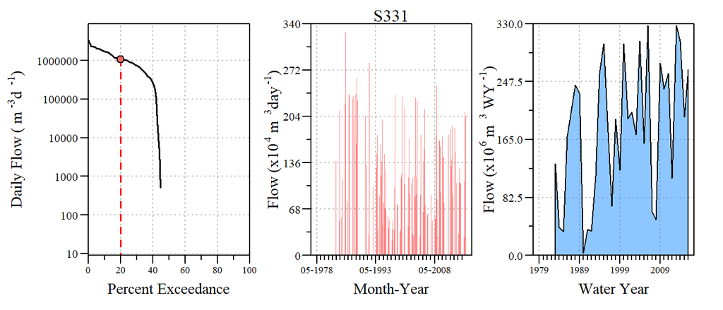

Daily Discharge Data Summary for the Period of Record (Units:m<sup>3</sup> d<sup>-1</sup>)

```
##    Min. 1st Qu.  Median    Mean 3rd Qu.    Max.
##       0       0       0  502005  947903 3387241
```

Daily Discharge Data Summary for the last 10-WYs (May 2005 - Apirl 2016; Units:m<sup>3</sup> d<sup>-1</sup>)

```
##    Min. 1st Qu.  Median    Mean 3rd Qu.    Max.
##       0       0   69189  601338 1069272 2993122
```

Water Year Discharge Data Summary for the Period of Record (Units:m<sup>3</sup> WY<sup>-1</sup>)

```
##      Min.   1st Qu.    Median      Mean   3rd Qu.      Max.
##   3247248 110676392 194768234 180323195 259369218 327449753
```

Water Year Discharge Data Summary for the last 10-WYs (2006-2016; Units:m<sup>3</sup> d<sup>-1</sup>)

```
##      Min.   1st Qu.    Median      Mean   3rd Qu.      Max.
##  50562343 153779872 259628183 219652473 289775981 327449753
```

## S173

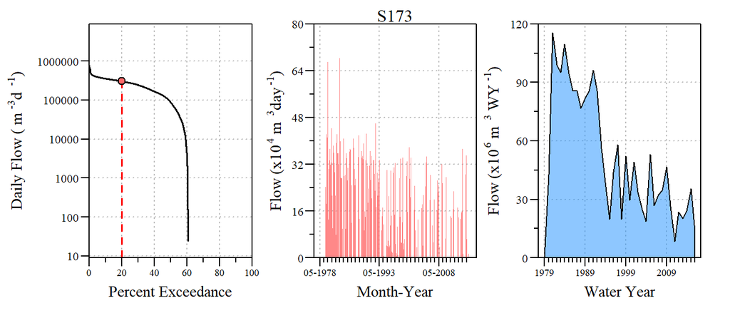

Daily Discharge Data Summary for the Period of Record (Units:m<sup>3</sup> d<sup>-1</sup>)

```
##    Min. 1st Qu.  Median    Mean 3rd Qu.    Max.
##       0       0   87820  140005  276396  779285
```

Daily Discharge Data Summary for the last 10-WYs (May 2005 - Apirl 2016; Units:m<sup>3</sup> d<sup>-1</sup>)

```
##    Min. 1st Qu.  Median    Mean 3rd Qu.    Max.
##       0       0       0   72612  146410  652454
```

Water Year Discharge Data Summary for the Period of Record (Units:m<sup>3</sup> WY<sup>-1</sup>)

```
##      Min.   1st Qu.    Median      Mean   3rd Qu.      Max.
##         0  25274560  43217478  51138476  84540073 115510577
```

Water Year Discharge Data Summary for the last 10-WYs (2006-2016; Units:m<sup>3</sup> d<sup>-1</sup>)

```
##     Min.  1st Qu.   Median     Mean  3rd Qu.     Max.
##  8378656 21754794 26477084 26523200 33420907 46643485
```

## S357

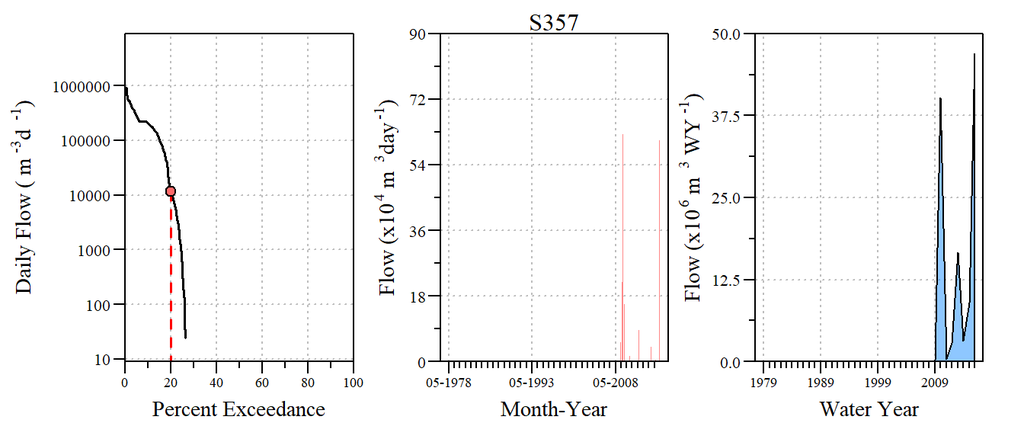

Daily Discharge Data Summary for the Period of Record (Units:m<sup>3</sup> d<sup>-1</sup>)

```
##     Min.  1st Qu.   Median     Mean  3rd Qu.     Max.
##      0.0      0.0      0.0  46334.0    391.5 938654.9
```

Daily Discharge Data Summary for the last 10-WYs (May 2005 - Apirl 2016; Units:m<sup>3</sup> d<sup>-1</sup>)

```
##     Min.  1st Qu.   Median     Mean  3rd Qu.     Max.
##      0.0      0.0      0.0  46334.0    391.5 938654.9
```

Water Year Discharge Data Summary for the Period of Record (Units:m<sup>3</sup> WY<sup>-1</sup>)

```
##     Min.  1st Qu.   Median     Mean  3rd Qu.     Max.
##   301003  2159290  6064790 14913758 22534360 46919337
```

Water Year Discharge Data Summary for the last 10-WYs (2006-2016; Units:m<sup>3</sup> d<sup>-1</sup>)

```
##     Min.  1st Qu.   Median     Mean  3rd Qu.     Max.
##   301003  2159290  6064790 14913758 22534360 46919337
```

## S332B

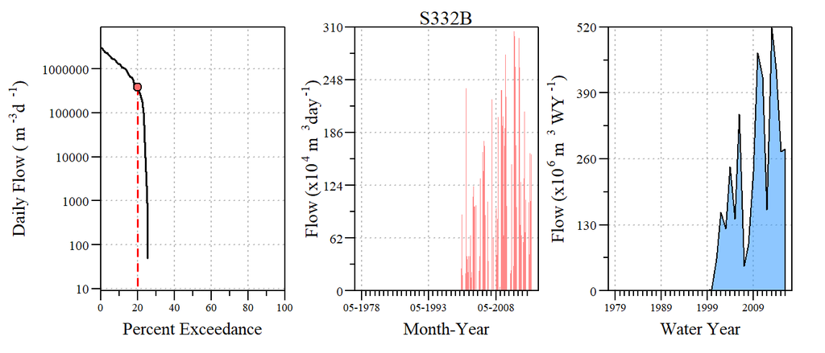

Daily Discharge Data Summary for the Period of Record (Units:m<sup>3</sup> d<sup>-1</sup>)

```
##    Min. 1st Qu.  Median    Mean 3rd Qu.    Max.
##       0       0       0  288898    1370 3094312
```

Daily Discharge Data Summary for the last 10-WYs (May 2005 - Apirl 2016; Units:m<sup>3</sup> d<sup>-1</sup>)

```
##    Min. 1st Qu.  Median    Mean 3rd Qu.    Max.
##       0       0  405105  816860 1620052 3094312
```

Water Year Discharge Data Summary for the Period of Record (Units:m<sup>3</sup> WY<sup>-1</sup>)

```
##      Min.   1st Qu.    Median      Mean   3rd Qu.      Max.
##         0         0         0 105523844 158670775 518418558
```

Water Year Discharge Data Summary for the last 10-WYs (2006-2016; Units:m<sup>3</sup> d<sup>-1</sup>)

```
##      Min.   1st Qu.    Median      Mean   3rd Qu.      Max.
##  48337032 196961226 278737612 298376799 429621405 518418558
```

## S332C

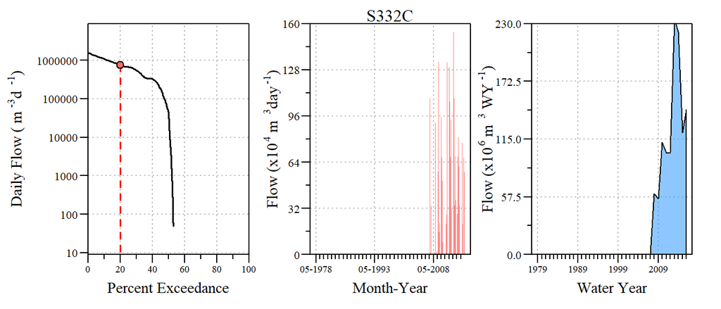

Daily Discharge Data Summary for the Period of Record (Units:m<sup>3</sup> d<sup>-1</sup>)

```
##    Min. 1st Qu.  Median    Mean 3rd Qu.    Max.
##       0       0   42766  347184  675941 1559793
```

Daily Discharge Data Summary for the last 10-WYs (May 2005 - Apirl 2016; Units:m<sup>3</sup> d<sup>-1</sup>)

```
##    Min. 1st Qu.  Median    Mean 3rd Qu.    Max.
##       0       0   42766  347184  675941 1559793
```

Water Year Discharge Data Summary for the Period of Record (Units:m<sup>3</sup> WY<sup>-1</sup>)

```
##      Min.   1st Qu.    Median      Mean   3rd Qu.      Max.
##    638729  70783572 106714376 115369295 138468825 234780056
```

Water Year Discharge Data Summary for the last 10-WYs (2006-2016; Units:m<sup>3</sup> d<sup>-1</sup>)

```
##      Min.   1st Qu.    Median      Mean   3rd Qu.      Max.
##    638729  70783572 106714376 115369295 138468825 234780056
```

## S174

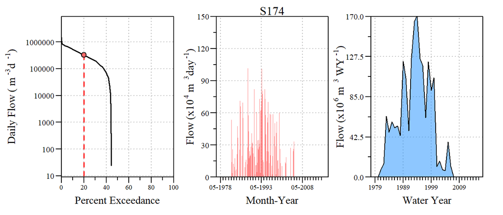

Daily Discharge Data Summary for the Period of Record (Units:m<sup>3</sup> d<sup>-1</sup>)

```
##    Min. 1st Qu.  Median    Mean 3rd Qu.    Max.
##       0       0       0  151500  254151 1506726
```

Water Year Discharge Data Summary for the Period of Record (Units:m<sup>3</sup> WY<sup>-1</sup>)

```
##      Min.   1st Qu.    Median      Mean   3rd Qu.      Max.
##         0   7715290  47501085  54489531 104671029 171300504
```

## S332DX1

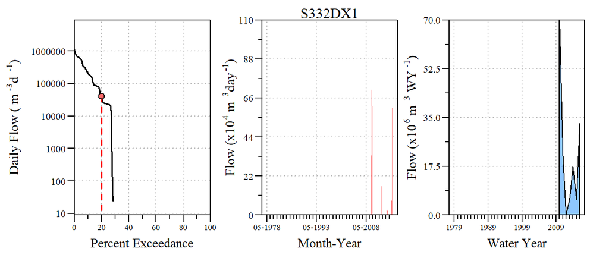

Daily Discharge Data Summary for the Period of Record (Units:m<sup>3</sup> d<sup>-1</sup>)

```
##    Min. 1st Qu.  Median    Mean 3rd Qu.    Max.
##       0       0       0   62577   23047 1094502
```

Daily Discharge Data Summary for the last 10-WYs (May 2005 - Apirl 2016; Units:m<sup>3</sup> d<sup>-1</sup>)

```
##    Min. 1st Qu.  Median    Mean 3rd Qu.    Max.
##       0       0       0   62577   23047 1094502
```

Water Year Discharge Data Summary for the Period of Record (Units:m<sup>3</sup> WY<sup>-1</sup>)

```
##     Min.  1st Qu.   Median     Mean  3rd Qu.     Max.
##      391  5736814 17269307 22339823 27042049 73551339
```

Water Year Discharge Data Summary for the last 10-WYs (2006-2016; Units:m<sup>3</sup> d<sup>-1</sup>)

```
##     Min.  1st Qu.   Median     Mean  3rd Qu.     Max.
##      391  5736814 17269307 22339823 27042049 73551339
```

## S332D

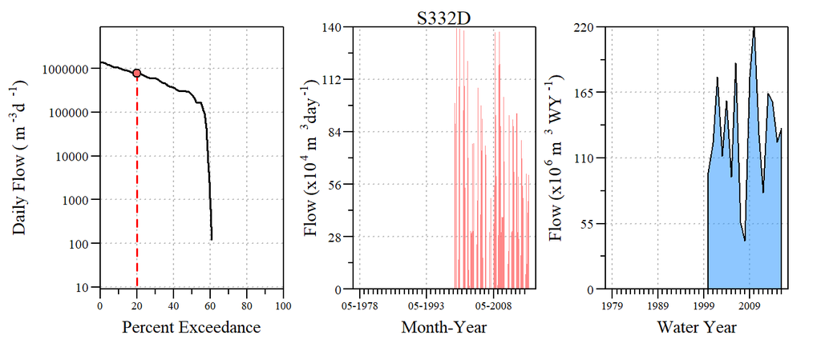

Daily Discharge Data Summary for the Period of Record (Units:m<sup>3</sup> d<sup>-1</sup>)

```
##    Min. 1st Qu.  Median    Mean 3rd Qu.    Max.
##       0       0  250456  365978  650521 1398392
```

Water Year Discharge Data Summary for the Period of Record (Units:m<sup>3</sup> WY<sup>-1</sup>)

```
##      Min.   1st Qu.    Median      Mean   3rd Qu.      Max.
##  40511255  97467050 129619246 131709078 164223013 223503622
```

## S176

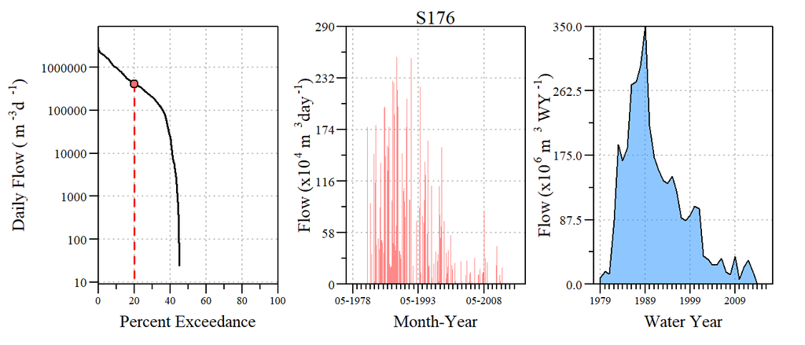

Daily Discharge Data Summary for the Period of Record (Units:m<sup>3</sup> d<sup>-1</sup>)

```
##    Min. 1st Qu.  Median    Mean 3rd Qu.    Max.
##       0       0       0  269512  304966 2903479
```

Daily Discharge Data Summary for the last 10-WYs (May 2005 - Apirl 2016; Units:m<sup>3</sup> d<sup>-1</sup>)

```
##    Min. 1st Qu.  Median    Mean 3rd Qu.    Max.
##       0       0       0   45473       0 1870435
```

Water Year Discharge Data Summary for the Period of Record (Units:m<sup>3</sup> WY<sup>-1</sup>)

```
##      Min.   1st Qu.    Median      Mean   3rd Qu.      Max.
##         0  19112267  86111249  98442821 152927459 350523816
```

Water Year Discharge Data Summary for the last 10-WYs (2006-2016; Units:m<sup>3</sup> d<sup>-1</sup>)

```
##     Min.  1st Qu.   Median     Mean  3rd Qu.     Max.
##        0  3301060 16335179 16609869 28502853 37756821
```

## S200

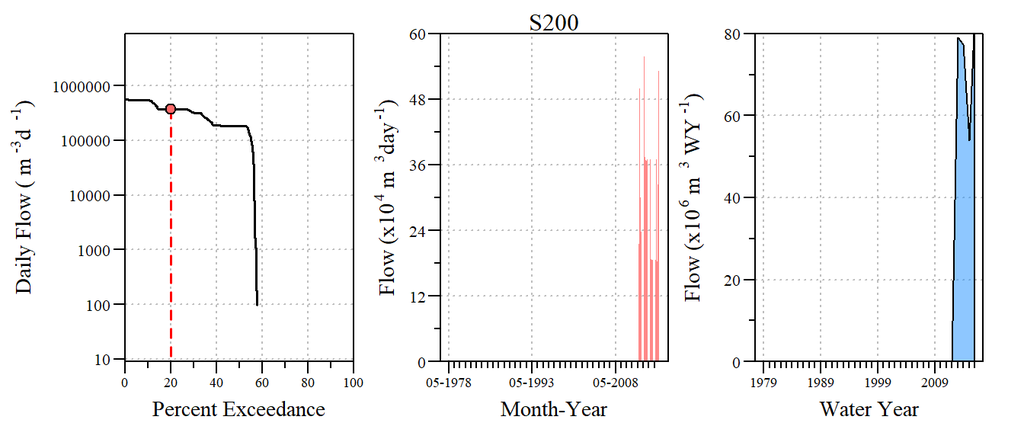

Daily Discharge Data Summary for the Period of Record (Units:m<sup>3</sup> d<sup>-1</sup>)

```
##    Min. 1st Qu.  Median    Mean 3rd Qu.    Max.
##       0       0  185977  187771  368663  562518
```

Daily Discharge Data Summary for the last 10-WYs (May 2005 - Apirl 2016; Units:m<sup>3</sup> d<sup>-1</sup>)

```
##    Min. 1st Qu.  Median    Mean 3rd Qu.    Max.
##       0       0  185977  187771  368663  562518
```

Water Year Discharge Data Summary for the Period of Record (Units:m<sup>3</sup> WY<sup>-1</sup>)

```
##     Min.  1st Qu.   Median     Mean  3rd Qu.     Max.
##        0 53925706 77347966 59035334 79131865 84771135
```

Water Year Discharge Data Summary for the last 10-WYs (2006-2016; Units:m<sup>3</sup> d<sup>-1</sup>)

```
##     Min.  1st Qu.   Median     Mean  3rd Qu.     Max.
##        0 53925706 77347966 59035334 79131865 84771135
```

## S332

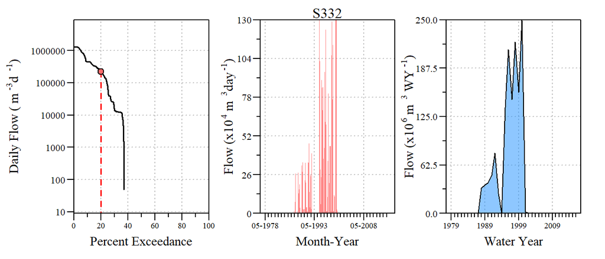

Daily Discharge Data Summary for the Period of Record (Units:m<sup>3</sup> d<sup>-1</sup>)

```
##    Min. 1st Qu.  Median    Mean 3rd Qu.    Max.
##       0       0       0  141390   73024 1321349
```

Daily Discharge Data Summary for the last 10-WYs (May 2005 - Apirl 2016; Units:m<sup>3</sup> d<sup>-1</sup>)

```
##     Min.  1st Qu.   Median     Mean  3rd Qu.     Max.
##    0.000    0.000    0.000    2.229    0.000 4354.912
```

Water Year Discharge Data Summary for the Period of Record (Units:m<sup>3</sup> WY<sup>-1</sup>)

```
##      Min.   1st Qu.    Median      Mean   3rd Qu.      Max.
##         0         0    593369  49486497  55953804 249380315
```

Water Year Discharge Data Summary for the last 10-WYs (2006-2016; Units:m<sup>3</sup> d<sup>-1</sup>)

```
##    Min. 1st Qu.  Median    Mean 3rd Qu.    Max.
##    0.00    0.00    0.00  788.34   48.93 5773.93
```

## S175

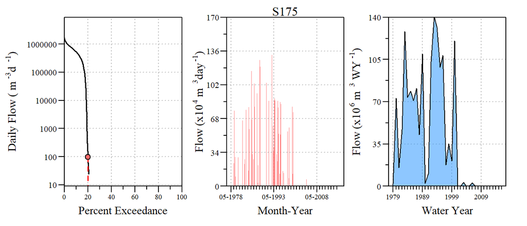

Daily Discharge Data Summary for the Period of Record (Units:m<sup>3</sup> d<sup>-1</sup>)

```
##    Min. 1st Qu.  Median    Mean 3rd Qu.    Max.
##       0       0       0  109368       0 1695235
```

Daily Discharge Data Summary for the last 10-WYs (May 2005 - Apirl 2016; Units:m<sup>3</sup> d<sup>-1</sup>)

```
##      Min.   1st Qu.    Median      Mean   3rd Qu.      Max.
##       0.0       0.0       0.0     659.7       0.0 1657239.9
```

Water Year Discharge Data Summary for the Period of Record (Units:m<sup>3</sup> WY<sup>-1</sup>)

```
##      Min.   1st Qu.    Median      Mean   3rd Qu.      Max.
##       220     11511  12681126  39947913  77431119 140912488
```

Water Year Discharge Data Summary for the last 10-WYs (2006-2016; Units:m<sup>3</sup> d<sup>-1</sup>)

```
##      Min.   1st Qu.    Median      Mean   3rd Qu.      Max.
##     220.2    1553.6    3400.7  240957.0   14985.3 2554743.3
```

## S199

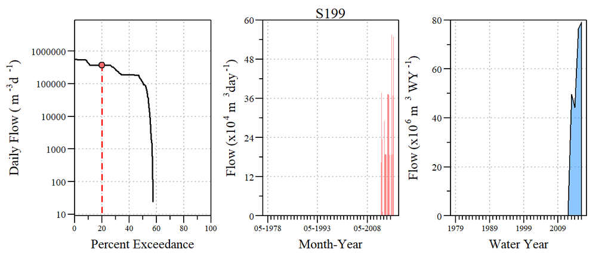

Daily Discharge Data Summary for the Period of Record (Units:m<sup>3</sup> d<sup>-1</sup>)

```
##    Min. 1st Qu.  Median    Mean 3rd Qu.    Max.
##       0       0  106842  167647  368559  561686
```

Daily Discharge Data Summary for the last 10-WYs (May 2005 - Apirl 2016; Units:m<sup>3</sup> d<sup>-1</sup>)

```
##    Min. 1st Qu.  Median    Mean 3rd Qu.    Max.
##       0       0  106842  167647  368559  561686
```

Water Year Discharge Data Summary for the Period of Record (Units:m<sup>3</sup> WY<sup>-1</sup>)

```
##     Min.  1st Qu.   Median     Mean  3rd Qu.     Max.
##        0 44200599 49584568 49891687 76430499 79242769
```

Water Year Discharge Data Summary for the last 10-WYs (2006-2016; Units:m<sup>3</sup> d<sup>-1</sup>)

```
##     Min.  1st Qu.   Median     Mean  3rd Qu.     Max.
##        0 44200599 49584568 49891687 76430499 79242769
```

## S177

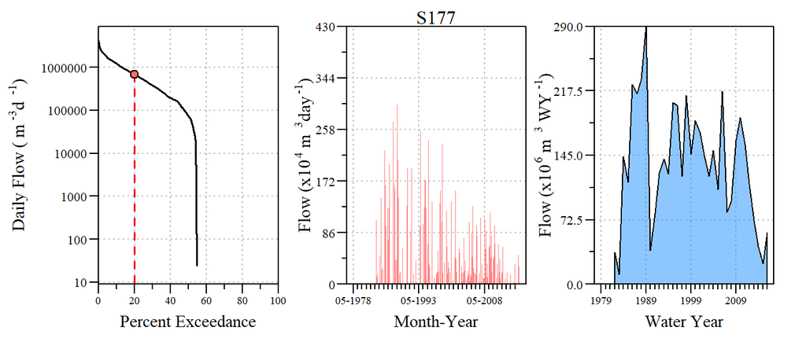

Daily Discharge Data Summary for the Period of Record (Units:m<sup>3</sup> d<sup>-1</sup>)

```
##    Min. 1st Qu.  Median    Mean 3rd Qu.    Max.
##       0       0   73777  373867  519415 4319584
```

Daily Discharge Data Summary for the last 10-WYs (May 2005 - Apirl 2016; Units:m<sup>3</sup> d<sup>-1</sup>)

```
##    Min. 1st Qu.  Median    Mean 3rd Qu.    Max.
##       0       0   88309  299787  475114 4319584
```

Water Year Discharge Data Summary for the Period of Record (Units:m<sup>3</sup> WY<sup>-1</sup>)

```
##      Min.   1st Qu.    Median      Mean   3rd Qu.      Max.
##  11147304  86951698 140927167 135404097 185848627 290952138
```

Water Year Discharge Data Summary for the last 10-WYs (2006-2016; Units:m<sup>3</sup> d<sup>-1</sup>)

```
##      Min.   1st Qu.    Median      Mean   3rd Qu.      Max.
##  22709645  64530493  92760099 109504021 159584089 217158441
```

## S178

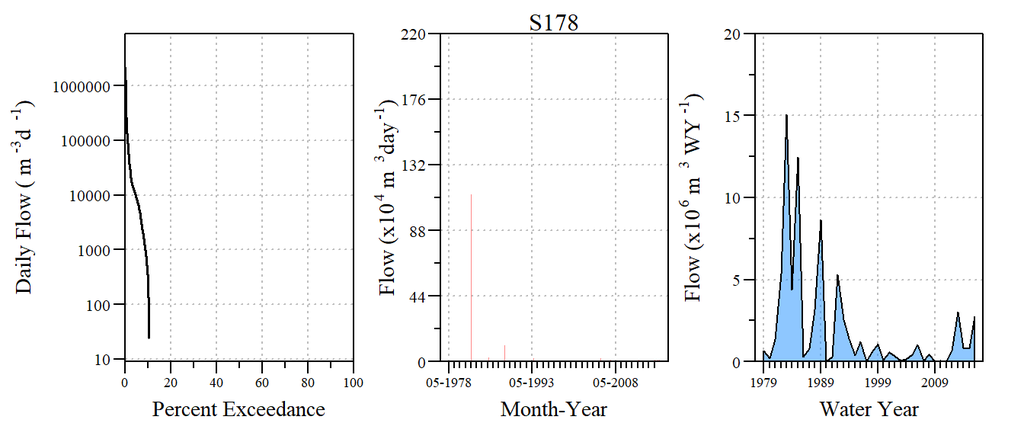

Daily Discharge Data Summary for the Period of Record (Units:m<sup>3</sup> d<sup>-1</sup>)

```
##    Min. 1st Qu.  Median    Mean 3rd Qu.    Max.
##       0       0       0    5517       0 2152330
```

Daily Discharge Data Summary for the last 10-WYs (May 2005 - Apirl 2016; Units:m<sup>3</sup> d<sup>-1</sup>)

```
##     Min.  1st Qu.   Median     Mean  3rd Qu.     Max.
##      0.0      0.0      0.0   2403.8    464.9 286470.0
```

Water Year Discharge Data Summary for the Period of Record (Units:m<sup>3</sup> WY<sup>-1</sup>)

```
##     Min.  1st Qu.   Median     Mean  3rd Qu.     Max.
##        0   206161   649200  2015229  2264769 15085123
```

Water Year Discharge Data Summary for the last 10-WYs (2006-2016; Units:m<sup>3</sup> d<sup>-1</sup>)

```
##    Min. 1st Qu.  Median    Mean 3rd Qu.    Max.
##       0   62608  634912  878026  946998 3028303
```

## S18C

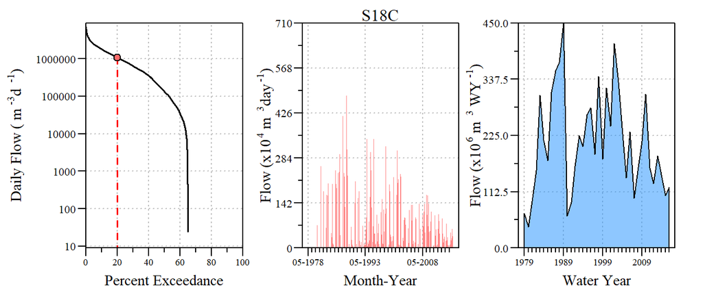

Daily Discharge Data Summary for the Period of Record (Units:m<sup>3</sup> d<sup>-1</sup>)

```
##    Min. 1st Qu.  Median    Mean 3rd Qu.    Max.
##       0       0  134672  582245  849012 7133175
```

Daily Discharge Data Summary for the last 10-WYs (May 2005 - Apirl 2016; Units:m<sup>3</sup> d<sup>-1</sup>)

```
##    Min. 1st Qu.  Median    Mean 3rd Qu.    Max.
##       0       0  265075  461110  761431 5362781
```

Water Year Discharge Data Summary for the Period of Record (Units:m<sup>3</sup> WY<sup>-1</sup>)

```
##      Min.   1st Qu.    Median      Mean   3rd Qu.      Max.
##  41675288 142212496 195043498 212672819 299418699 449567026
```

Water Year Discharge Data Summary for the last 10-WYs (2006-2016; Units:m<sup>3</sup> d<sup>-1</sup>)

```
##      Min.   1st Qu.    Median      Mean   3rd Qu.      Max.
##  99119788 125303136 153354644 168430886 198789127 307577481
```

## S197

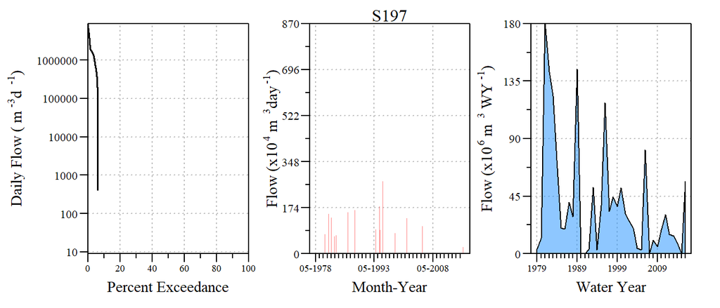

Daily Discharge Data Summary for the Period of Record (Units:m<sup>3</sup> d<sup>-1</sup>)

```
##    Min. 1st Qu.  Median    Mean 3rd Qu.    Max.
##       0       0       0  107514       0 8661064
```

Daily Discharge Data Summary for the last 10-WYs (May 2005 - Apirl 2016; Units:m<sup>3</sup> d<sup>-1</sup>)

```
##    Min. 1st Qu.  Median    Mean 3rd Qu.    Max.
##       0       0       0   59822       0 6839096
```

Water Year Discharge Data Summary for the Period of Record (Units:m<sup>3</sup> WY<sup>-1</sup>)

```
##      Min.   1st Qu.    Median      Mean   3rd Qu.      Max.
##         0   6151094  22890227  39271072  49592856 180915196
```

Water Year Discharge Data Summary for the last 10-WYs (2006-2016; Units:m<sup>3</sup> d<sup>-1</sup>)

```
##     Min.  1st Qu.   Median     Mean  3rd Qu.     Max.
##        0  6902291 13941738 21851311 24606882 81209281
```

# Water Quality Information

Provided in this section are peroid of record water quality data and summarise of data located in the South Florida Water Management Districts [DBHYDRO](http://my.sfwmd.gov/dbhydroplsql/show_dbkey_info.main_menu). All structure-water quality monitoring location pairings used to construct these water quality time-series can be found in this [file](http://publicfiles.dep.state.fl.us/owp/SouthDade_Info/DataInventory_existing.xlsx).

Below are a series of plots for each structure with accessible/available data. The data are presented both as individual grab samples (i.e. raw data) and annual flow-weighted mean concentrations based on the Florida water year (May 1 - Apirl 30). Water quality data were screened for fatal qualifiers and paired with flow data for each structure with available data. Flow-weighted mean concentrations were calcualted for structures with greater than three samples per year using only positive flow. Similar to the plots above for discharge data, three plots were developed to represent each structure and the associated water quality (Total Phosphorus). The three plots include (1) the top left plot displaying a percent exceedance curve for all data (solid line) and only flowing conditions (dashed line) based on grab sample (weekly, biweekly or monthly depending on structure); (2) top right plot displays raw grab sample total phosphorus concentration with points color coded relative to flowing conditions (blue: flowing, red: not flowing); (3) bottom plot displays annual flow-weighted mean concentrations and weighted-standard error (FWM $\pm$ SE<sub>wtd</sub>). All concentrations are expressed as $\mu$g L<sup>-1</sup> (i.e. parts-per-billion).

## S331

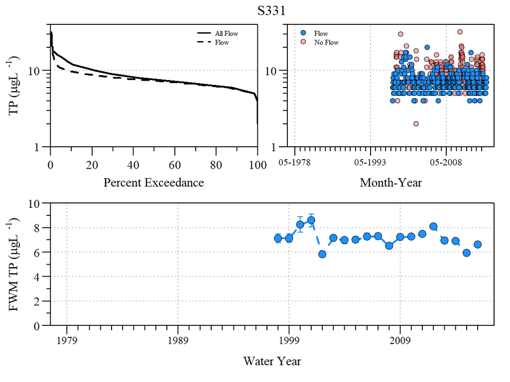

## S173

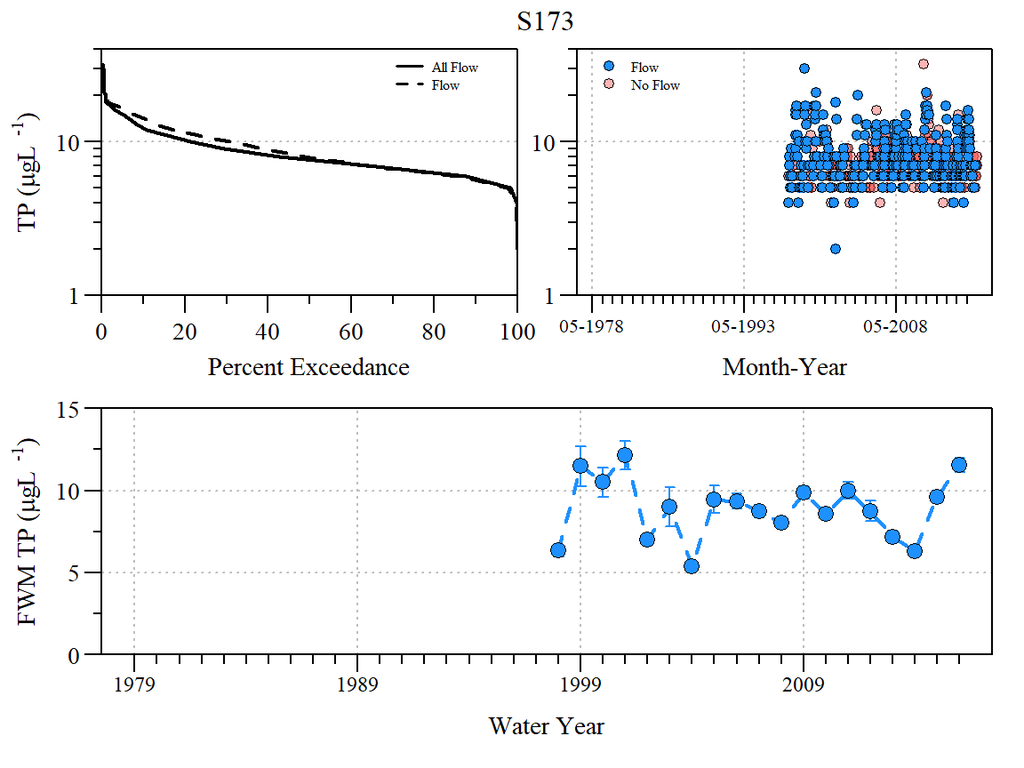

## S357

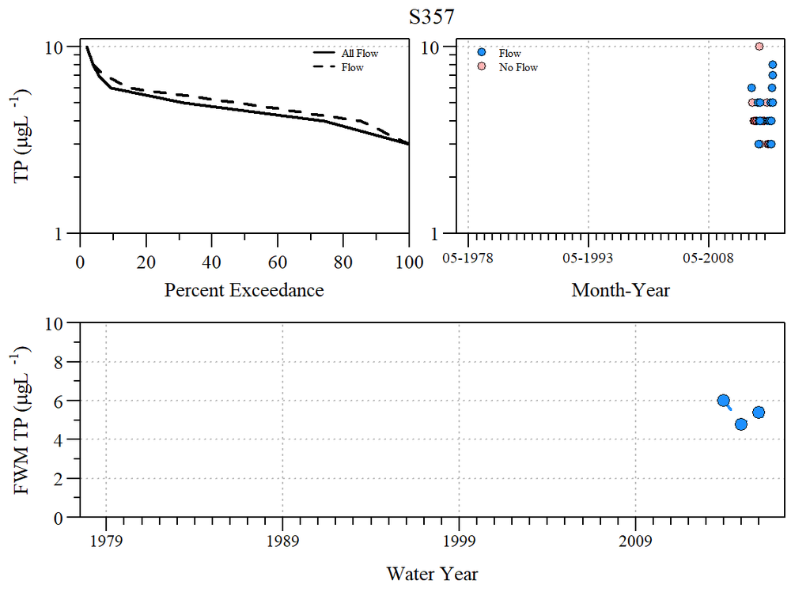

## S332B

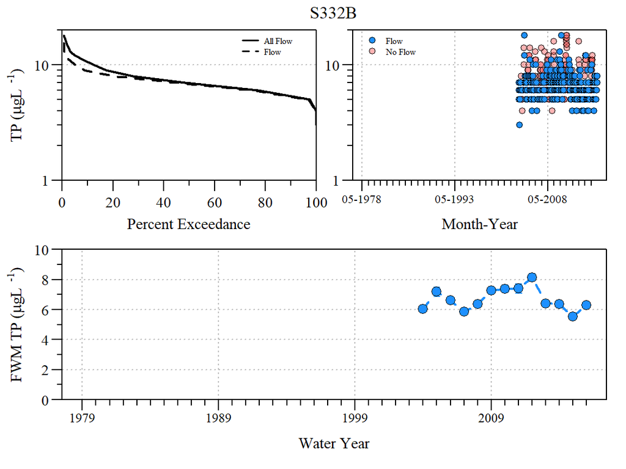

## S332C

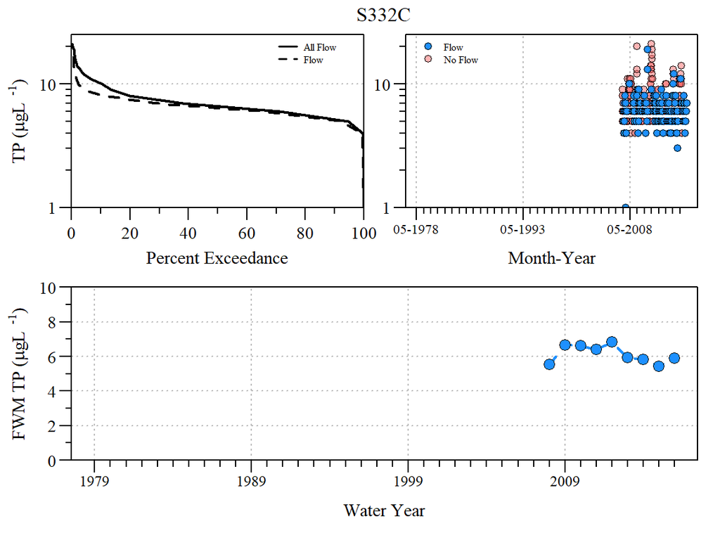

## S174

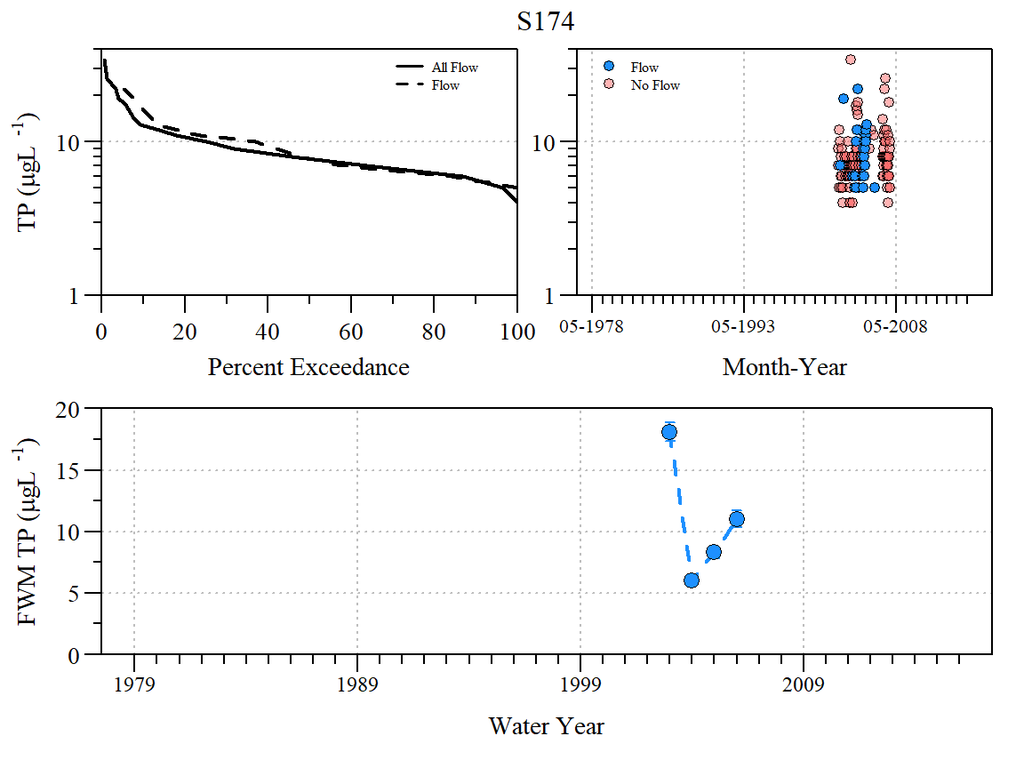

## S332D

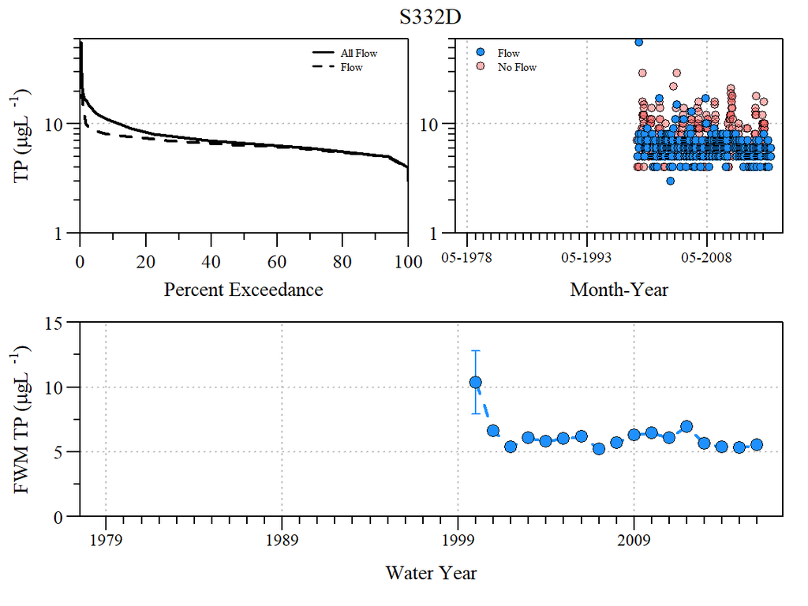

## S176

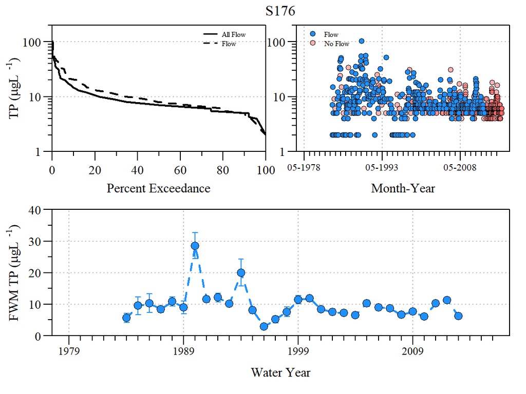

## S200

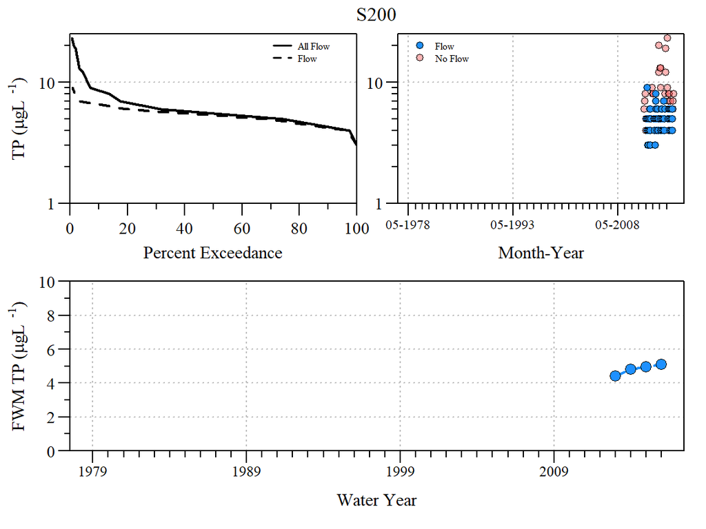

## S332

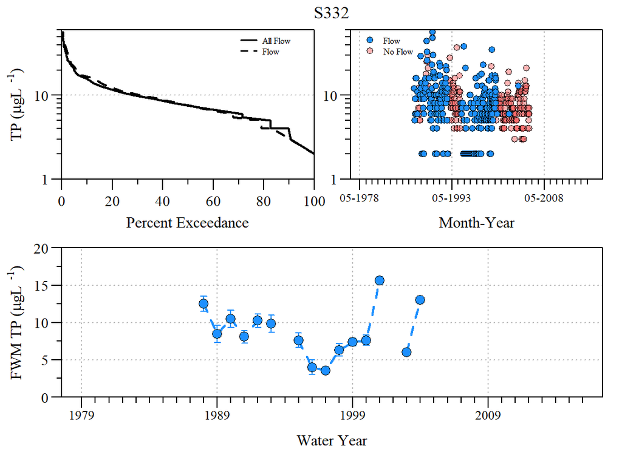

## S175

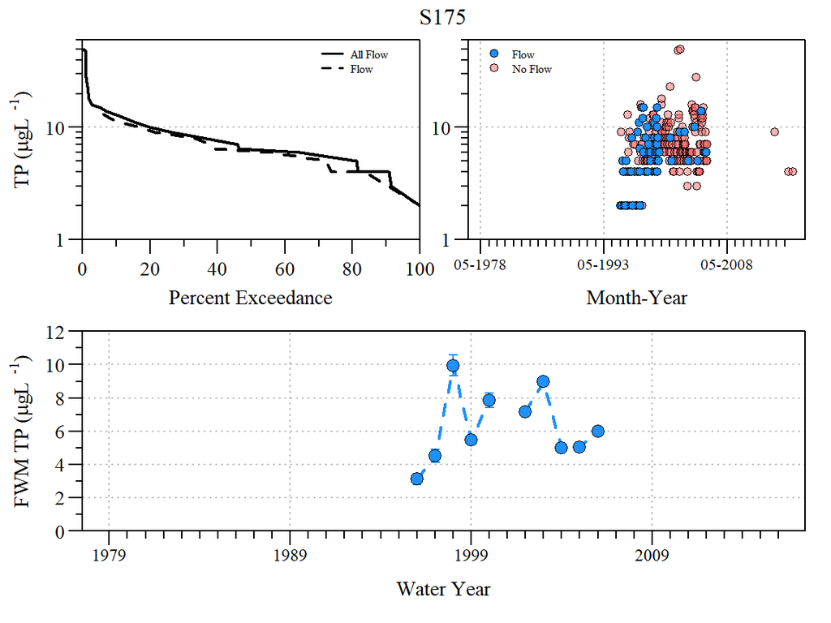

## S199

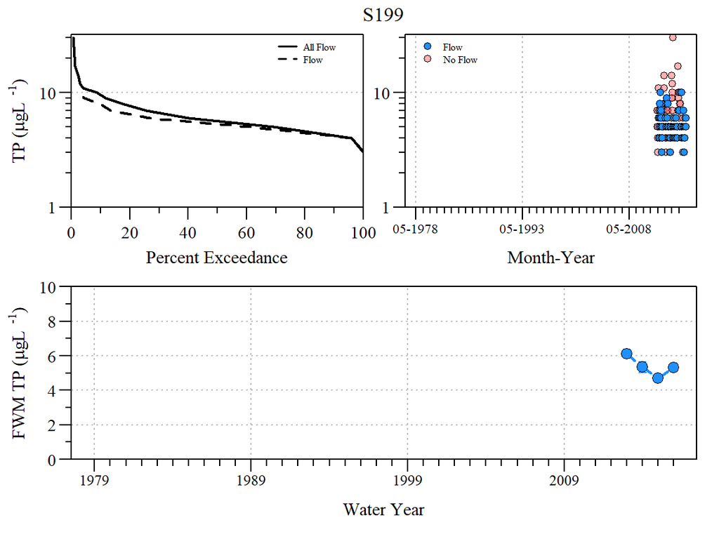

## S177

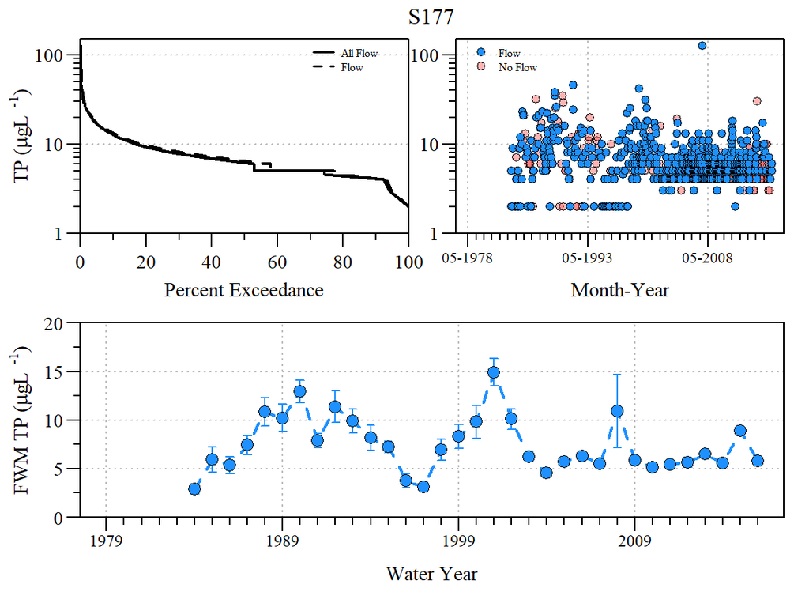

## S178

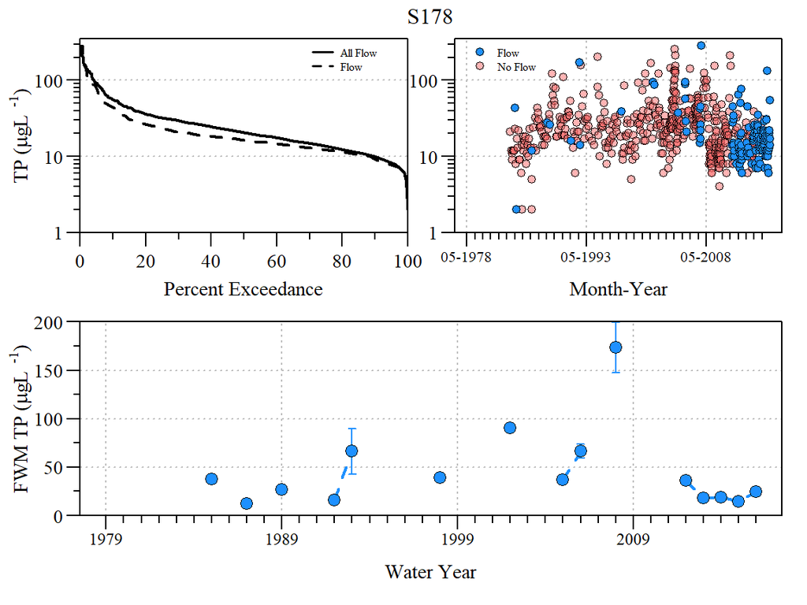